# Lab: Simulation vs. Mathematical Models for Proportions

## Getting started

Today we revisit case studies from lecture and solve each one **two ways**: by simulation (what we already know) and using R’s built-in mathematical-model function, `prop.test()`. The goal is to see when they agree, when they don’t, and why.

```r
library(tidyverse)
library(openintro)
data(sex_discrimination)
data(opportunity_cost)
data(cpr)
```

## Part 1: One proportion — the medical consultant

Recall: a consultant’s clients had 3 complications out of 62 liver-donor surgeries, versus a national rate of 10%. $H_0: p = 0.10$.

**Important:** per our discussion on two-sided tests, this really should be a two-sided question — we’d care if her rate were *either* better or worse than 10%. Let’s test it that way this time (lecture only did a one-sided version).

### Simulating the null distribution

Simulate what $\hat{p}$ would look like across many samples of 62 patients, **if** the true rate really were 10%:

```r
set.seed(2026)
n_reps <- 10000

null_sim <- rbinom(n_reps, size = 62, prob = 0.10) / 62

obs_p <- 3 / 62

# Two-sided simulated p-value: how often is a simulated p-hat at least as far
# from 0.10 as our observed value, in EITHER direction?
mean(abs(null_sim - 0.10) >= abs(obs_p - 0.10))
```

```
[1] 0.2107
```

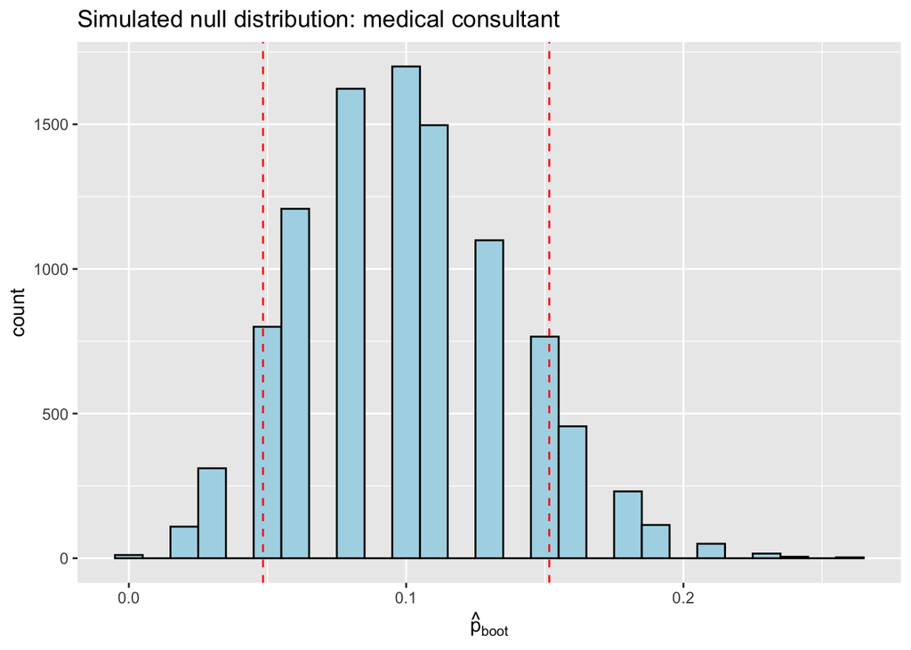

```r
tibble(p_hat = null_sim) %>%
  ggplot(aes(x = p_hat)) +
  geom_histogram(binwidth = 0.01, fill = "lightblue", color = "black") +
  geom_vline(xintercept = obs_p, color = "red", linetype = "dashed") +
  geom_vline(xintercept = 0.10 + (0.10 - obs_p), color = "red", linetype = "dashed") +
  labs(title = "Simulated null distribution: medical consultant",
       x = expression(hat(p)[boot]), y = "count")
```

**Try it:** Does your simulated two-sided p-value roughly match the value mentioned in lecture (~0.244, doubling the one-sided ~0.122)?

### The mathematical-model version

```r
prop.test(x = 3, n = 62, p = 0.10, alternative = "two.sided")
```

```
    1-sample proportions test with continuity correction

data:  3 out of 62, null probability 0.1
X-squared = 1.3065, df = 1, p-value = 0.253
alternative hypothesis: true p is not equal to 0.1
95 percent confidence interval:
 0.0125801 0.1437904
sample estimates:
        p
0.0483871
```

**Discuss:**

1. Compare this p-value to your simulation and to lecture’s normal-model calculation ($Z=-1.37$, one-sided $p\approx0.085$, doubled $\approx0.171$). They won’t match exactly — why not? (Hint: think about what lecture said about this null distribution’s *shape*.)
2. By default, `prop.test()` applies a **continuity correction**. Try adding `correct = FALSE` and see if the p-value moves closer to the hand-calculated normal-model answer.

```r
# TODO: re-run prop.test with correct = FALSE and compare
```

## Part 2: Two proportions — the CPR study

Recall the blood-thinner study: does it change 24-hour survival after CPR? This was our two-sided example in lecture.

```r
glimpse(cpr)
```

```
Rows: 90
Columns: 2
$ group   <fct> control, control, control, control, control, control, control,…
$ outcome <fct> survived, survived, survived, survived, survived, survived, su…
```

```r
table(cpr)
```

```
           outcome
group       died survived
  control     39       11
  treatment   26       14
```

### Simulating the null distribution (two-sided)

```r
set.seed(2026)
n_reps <- 10000

pooled <- cpr$outcome
n_trmt <- sum(cpr$group == "treatment")
n_ctrl <- sum(cpr$group == "control")

obs_diff <- mean(cpr$outcome[cpr$group == "treatment"] == "survived") -
            mean(cpr$outcome[cpr$group == "control"] == "survived")

sim_diffs <- replicate(n_reps, {
  shuffled <- sample(pooled)
  p_trmt <- mean(shuffled[1:n_trmt] == "survived")
  p_ctrl <- mean(shuffled[(n_trmt + 1):(n_trmt + n_ctrl)] == "survived")
  p_trmt - p_ctrl
})

# Two-sided p-value
mean(abs(sim_diffs) >= abs(obs_diff))
```

```
[1] 0.2351
```

**Check:** does this roughly match lecture’s reported two-sided p-value of ~0.26?

### The mathematical-model version

```r
prop.test(x = c(14, 11), n = c(40, 50), alternative = "two.sided")
```

```
    2-sample test for equality of proportions with continuity correction

data:  c(14, 11) out of c(40, 50)
X-squared = 1.2801, df = 1, p-value = 0.2579
alternative hypothesis: two.sided
95 percent confidence interval:
 -0.07966886  0.33966886
sample estimates:
prop 1 prop 2
  0.35   0.22
```

**Discuss:**

1. What confidence interval does `prop.test()` report for the difference in survival proportions? Does it contain 0? What does that tell you about the conclusion?
2. Compare this p-value to your simulation above and to lecture’s normal-model version. How well do they agree this time, compared to the medical consultant case? Why might that be (think about sample size and how close $\hat{p}$ is to 0 or 1 in each case)?

## Part 3: In-class exercise — your choice

Pick **one** of the two remaining case studies below and solve it **both ways** (simulation and `prop.test()`), then compare.

**Option A: Sex discrimination** (`sex_discrimination`, columns `sex`, `decision`) — originally a one-sided test. Redo it as **two-sided** this time.

**Option B: Opportunity cost** (`opportunity_cost`, columns `group`, `decision`) — also originally one-sided; redo as **two-sided**.

```r
# TODO: simulation-based two-sided test

# TODO: prop.test() version
```

**Answer these:**

1. State $H_0$ and $H_A$ (two-sided) in your own words and in symbols.
2. Report both p-values (simulation and `prop.test()`). Do they lead to the same conclusion at $\alpha = 0.05$?
3. Check the success-failure condition ($n\hat{p} \ge 10$ and $n(1-\hat{p}) \ge 10$ for each group) for your chosen case study. Based on what you saw in Part 1, would you expect the normal model to be trustworthy here?

## Wrapping up

- `prop.test()` gives you, in one line, everything we’ve been computing by hand: a Z-based (technically chi-square, which is equivalent here) p-value **and** a confidence interval.
- It’s fast — but it’s still trusting the normal approximation, so the **success-failure condition still matters**. When it’s violated (small $n$, or $p$ near 0 or 1), simulation-based methods are more trustworthy, even though they take more code to run.
- Next week: we move from proportions to **means**, and meet `t.test()` — the mathematical-model tool for exactly that setting.